# Bivariate Data

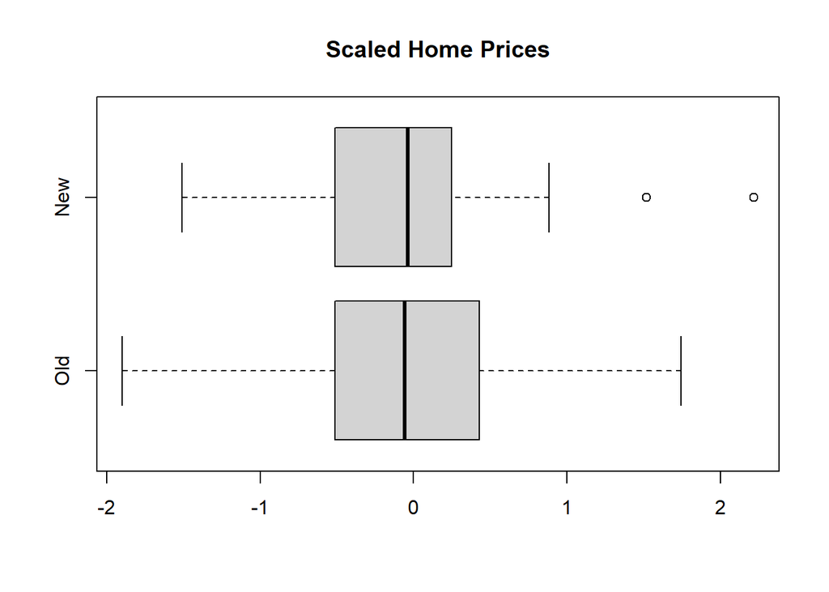

```r
> boxplot(c(scale(home$old)), c(scale(home$new)),
+         horizontal = TRUE,
+         main = "Scaled Home Prices",
+         names = c("Old", "New"))
```

Another example with different data frame on the same house prices

```r
> library(MASS)
```

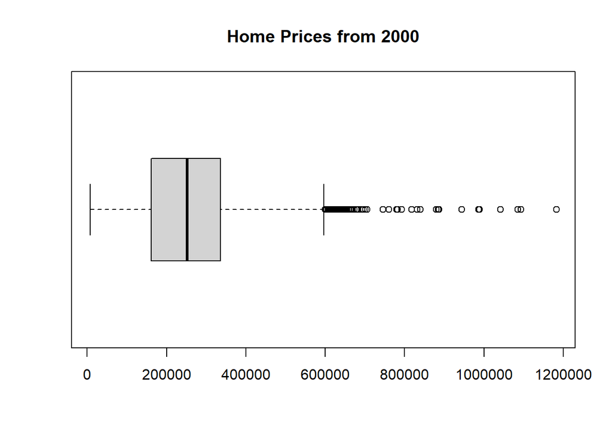

```r
> head(homedata)
   y1970  y2000
1  89700 359100
2 118400 504500
3 116400 477300
4 122000 500400
5  91500 433900
6 102800 464800
> boxplot(homedata$y2000,
+         horizontal = TRUE,
+         main = "Home Prices from 2000")
```

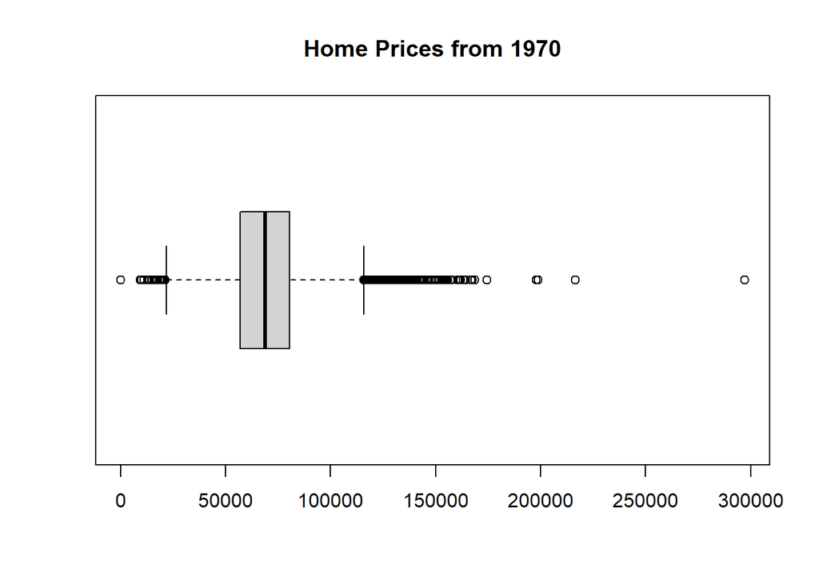

```r
> boxplot(homedata$y1970,
+         horizontal = TRUE,
+         main = "Home Prices from 1970")
```

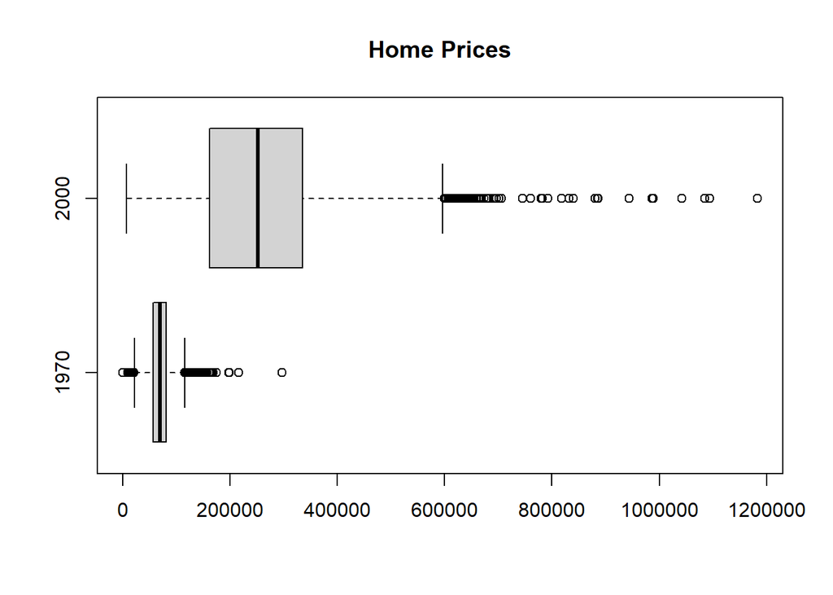

```r
> boxplot(homedata$y1970, homedata$y2000,
+         horizontal = TRUE,
+         main = "Home Prices",
+         names = c("1970", "2000"))
```

```r
> head(homedata$y1970)
[1]  89700 118400 116400 122000  91500 102800
> mean(homedata$y1970)
[1] 70821
> sd(homedata$y1970)
[1] 22284
> head((homedata$y1970 - mean(homedata$y1970)) / sd(homedata$y1970))
[1] 0.847 2.135 2.045 2.297 0.928 1.435
> head(scale(homedata$y1970))
      [,1]
[1,] 0.847
[2,] 2.135
[3,] 2.045
[4,] 2.297
[5,] 0.928
[6,] 1.435
```

```r
> head(homedata$y2000)
[1] 359100 504500 477300 500400 433900 464800
> mean(homedata$y2000)
[1] 268370
> sd(homedata$y2000)
[1] 130734
> head((homedata$y2000 - mean(homedata$y2000)) / sd(homedata$y2000))
[1] 0.694 1.806 1.598 1.775 1.266 1.503
> head(scale(homedata$y2000))
      [,1]
[1,] 0.694
[2,] 1.806
[3,] 1.598
[4,] 1.775
[5,] 1.266
[6,] 1.503
```

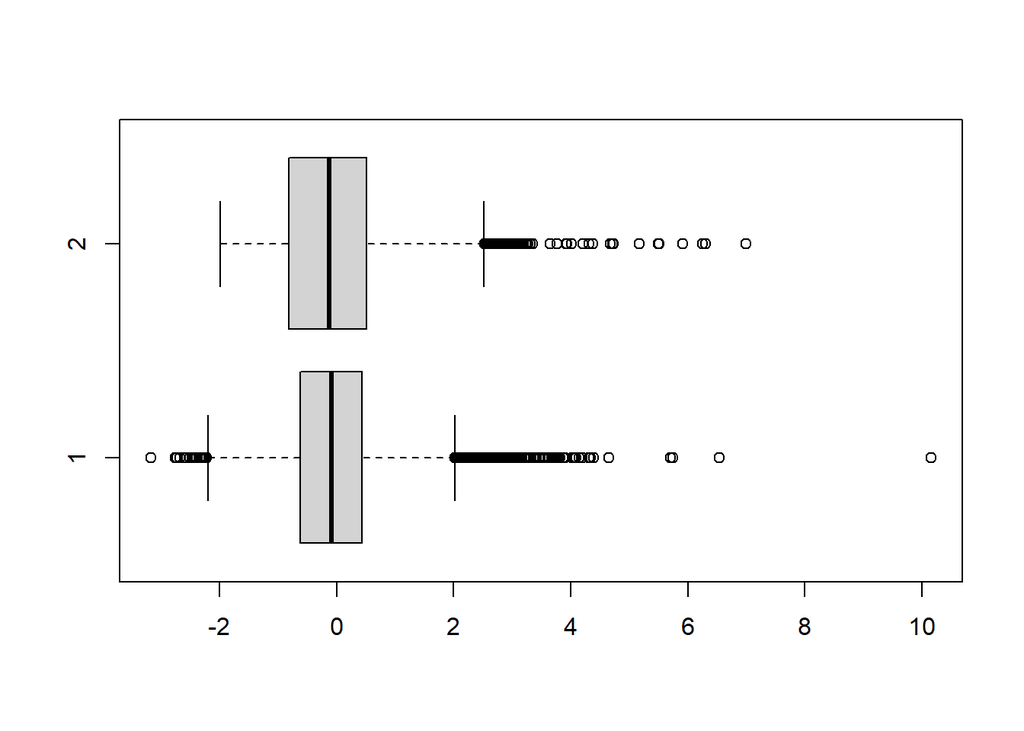

```r
> boxplot(c(scale(homedata$y1970)), c(scale(homedata$y2000)), horizontal = TRUE)
```

Also we can present the two distributions using stripcharts or dotplots

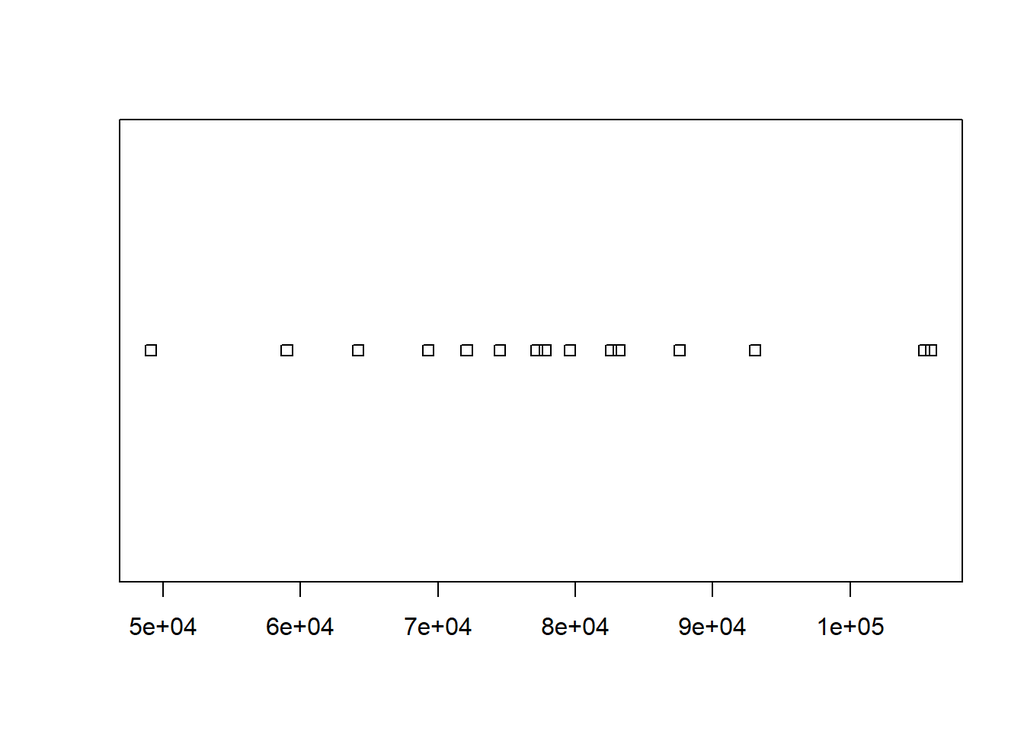

```r
> stripchart(home$old)
```

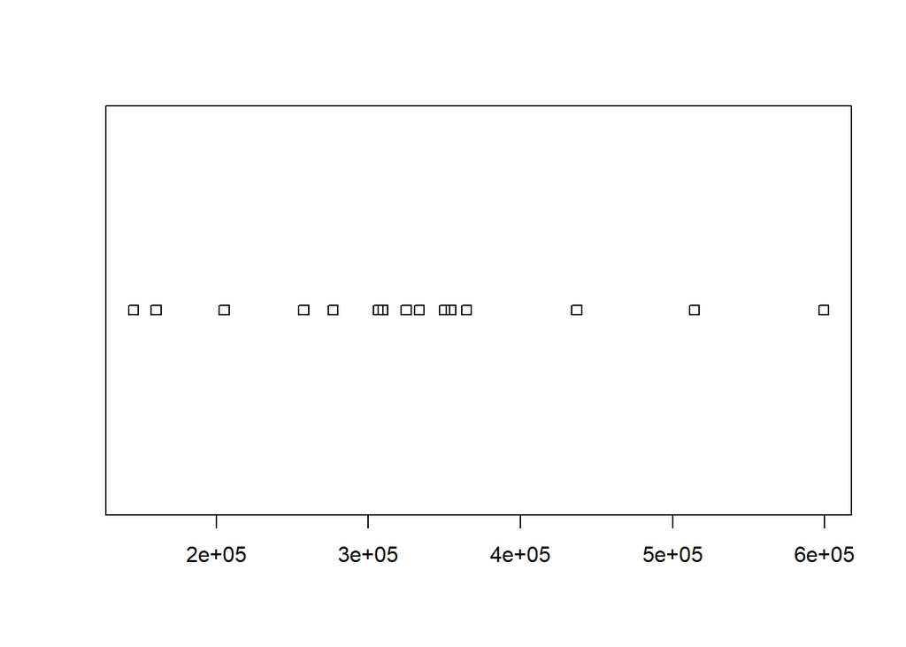

```r
> stripchart(home$new)
```

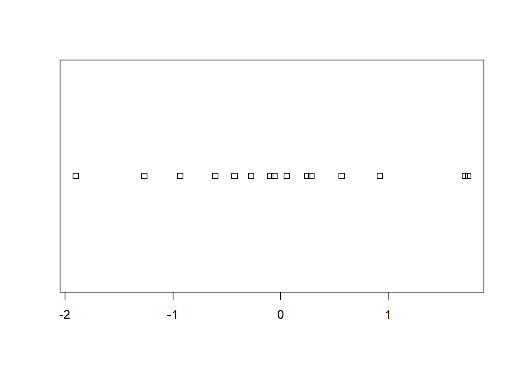

```r
> stripchart(scale(home$old))
```

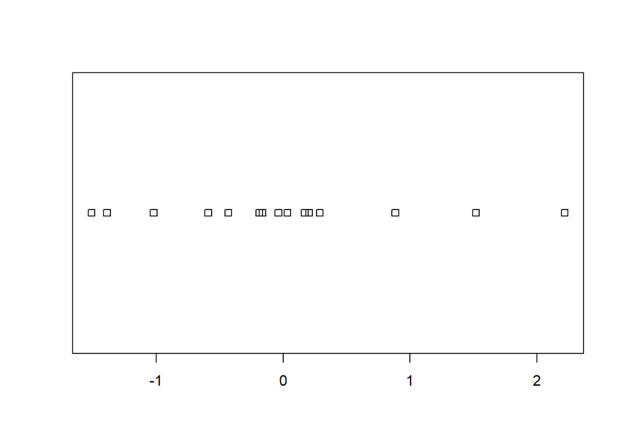

```r
> stripchart(scale(home$new))
```

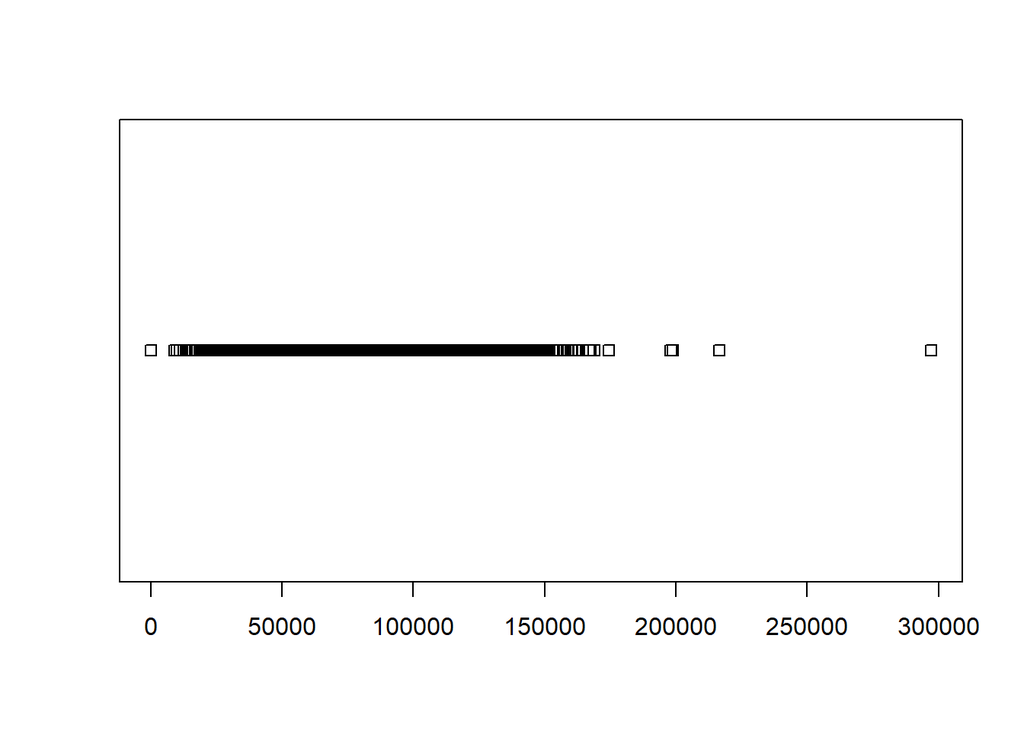

```r
> stripchart(homedata$y1970)
```

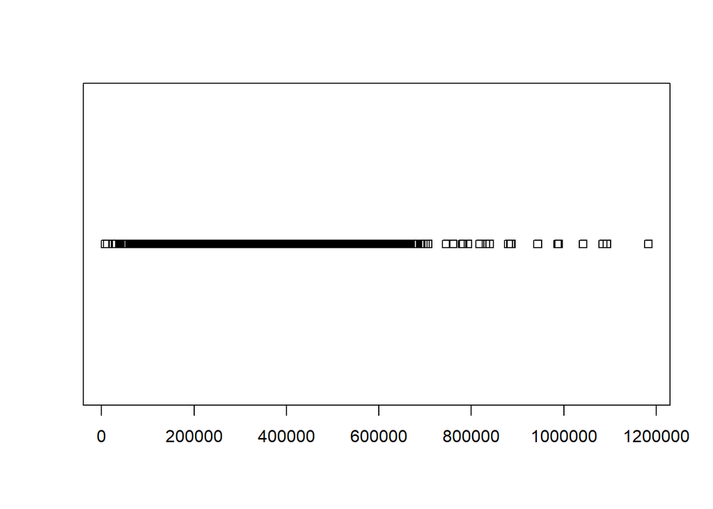

```r
> stripchart(homedata$y2000)
```

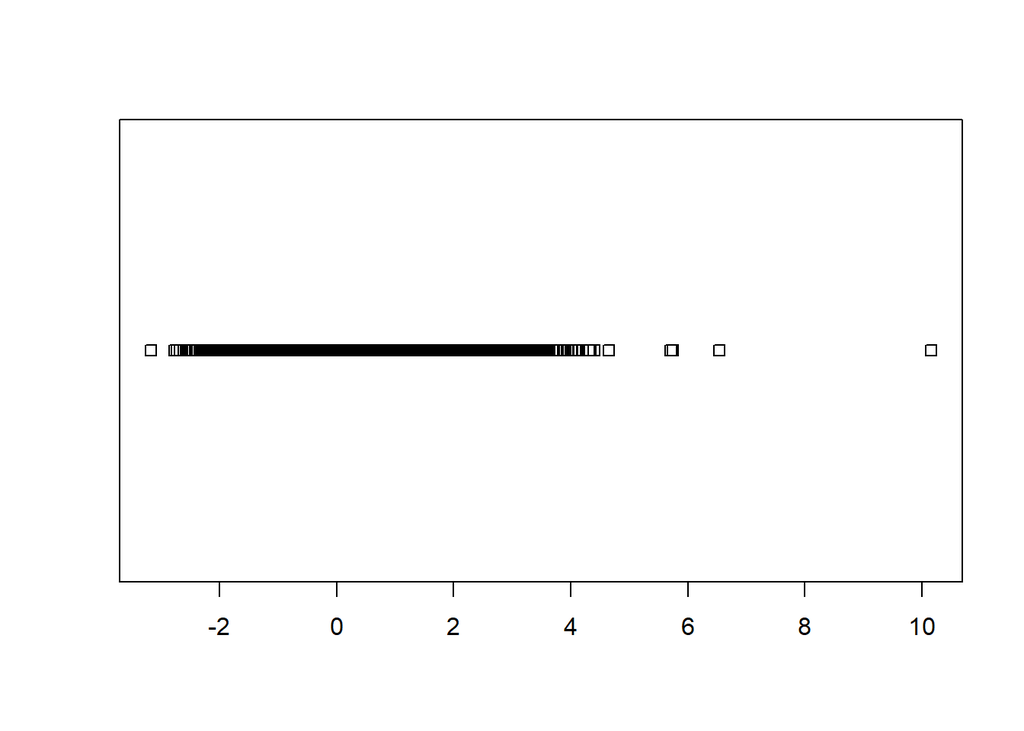

```r
> stripchart(scale(homedata$y1970))
```

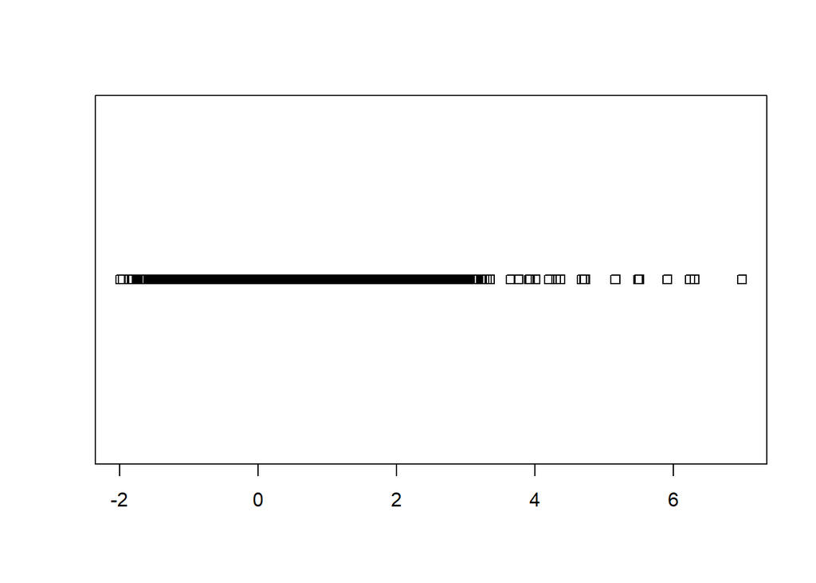

```r
> stripchart(scale(homedata$y2000))
```

We can also compare shapes of distributions using the violin plots

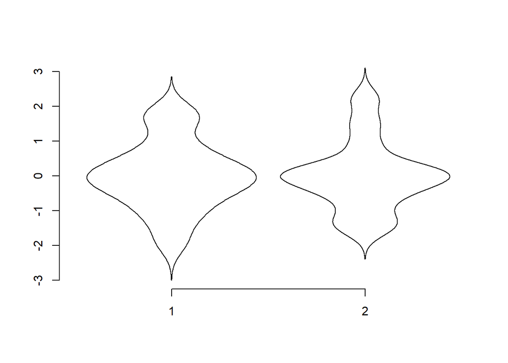

```r
> violinplot(scale(home$old), scale(home$new))
> simple.violinplot(scale(home$old),scale(home$new))
```

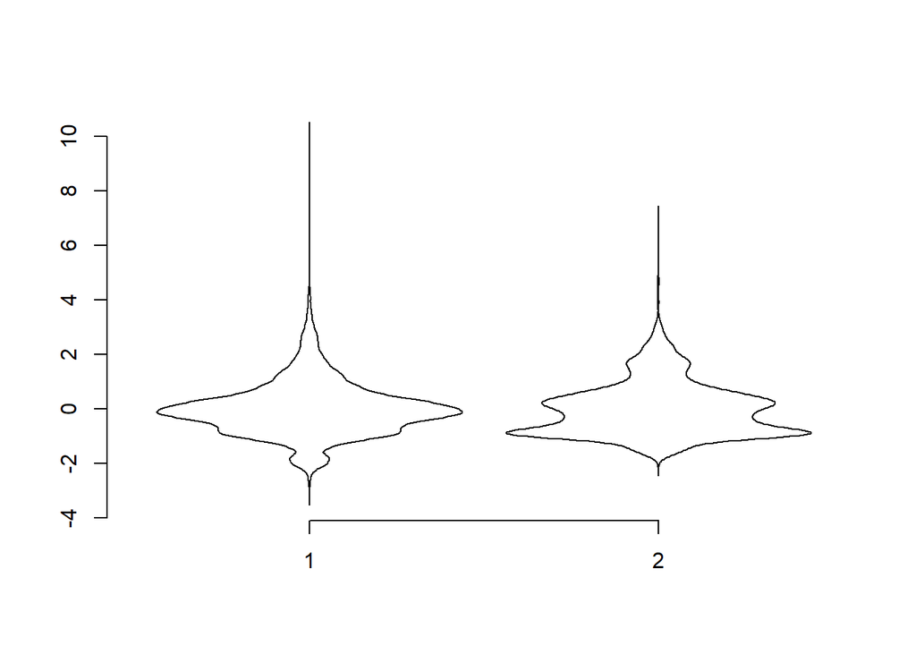

```r
> violinplot(scale(homedata$y1970), scale(homedata$y2000))
> simple.violinplot(scale(homedata$y1970),scale(homedata$y2000))
```

#### Comparing relationships

To investigate one numerical variable against another, we can use the scatter plot

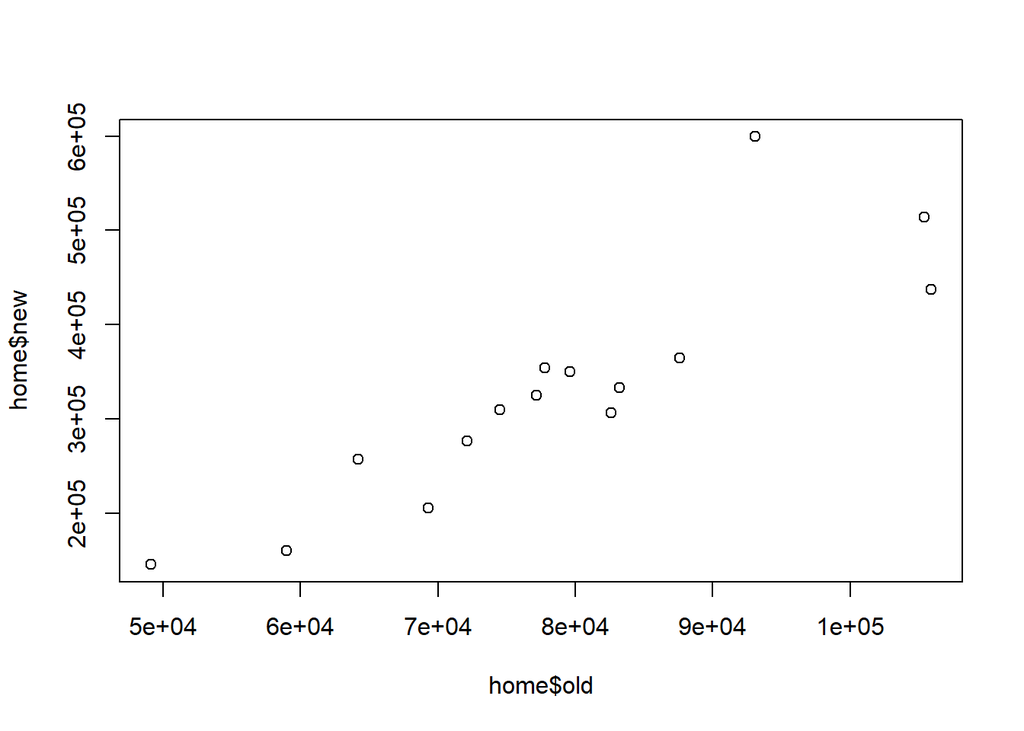

```r
> plot(home$old, home$new)
```

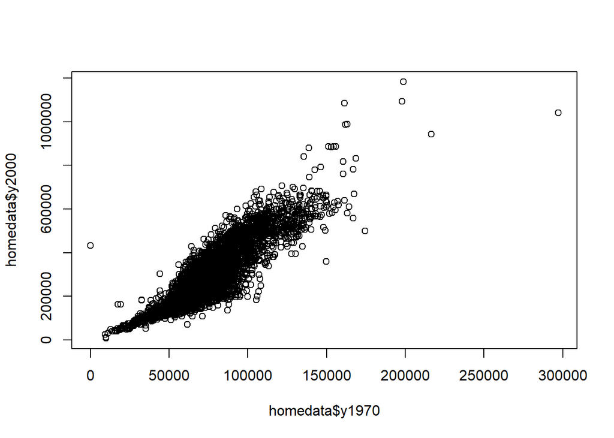

```r
> plot(homedata$y1970, homedata$y2000)
```

It looks like we have a strong linear trend. The modeling of such relationships is a common statistical practice. It allows us to make predictions of the y variable based on the value of the x variable.

#### Pearson correlation coefficient $R$

The Pearson correlation coefficient indicates the strength of a linear relationship between two variables.
$$R = \frac{\sum{(x_i - \bar{X})(y_i - \bar{Y})}}{\sqrt{\sum{(x_i - \bar{X})^2 \sum{(y_i - \bar{Y})^2}}}} \in [-1, 1]$$
This is a scaled covariance between X and Y. It measures how one variable varies as the other does. A value of

- -1 indicates strong negative linear relationship
- 0 indicates no linear relationship
- +1 indicates strong positive linear relationship

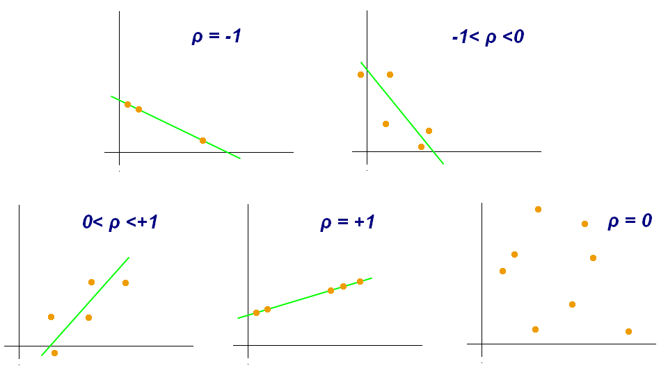

Pearson correlation value generally does not completely characterize their relationship.

The following image displays four data sets called Anscombe’s quartet. In each case, the mean and standard deviation of each variable is the same, and the correlation between the two random variables is $0.816$. However, the data look very different when graphed.

[figure not shown]

Time for some practice. Let’s play some funny online games to predict correlations [Game 1](http://istics.net/Correlations/), [Game 2](http://guessthecorrelation.com/)

```r
> cov(home$old, home$new)
[1] 1.67e+09
> cov(homedata$y1970, homedata$y2000)
[1] 2.61e+09
```

```r
> cor(home$old, home$new)
[1] 0.881
> cor(homedata$y1970, homedata$y2000)
[1] 0.896
```

#### Spearman rank correlation

Same thing only applied to the ranks of the data.

```r
> cor(rank(home$old), rank(home$new))
[1] 0.925
> cor(rank(homedata$y1970), rank(homedata$y2000))
[1] 0.888
```

or

```r
> cor(home$old, home$new, method = "spearman")
[1] 0.925
> cor(homedata$y1970, homedata$y2000, method = "spearman")
[1] 0.888
```

Spearman rank correlation is close to 1 (or -1) if there is a strong increasing (decreasing) trend in the data. (**The trend need not be linear.**)

[figure not shown]

When the data are roughly elliptically distributed and there are no prominent outliers, the Spearman correlation and Pearson correlation give similar values.

[figure not shown]

The Spearman correlation is less sensitive than the Pearsin correlation to strong outliers that are in the tails of both samples.

[figure not shown]

#### Simple linear regression

**Linear regression** is the name of a procedure that fits a straight line to the data. The idea is that the $x$ value is something the experimenter controls, the $y$ value one the experimenter measures. The line is used to predict the value of $y$ for a known value of $x$. The variable $x$ is the **predictor** variable and $y$ the **response** variable.

Suppose we write the equation of the line as
$$\hat{y} = b_0 + b_1x$$
Then, for each $x_i$ the predicted value would be
$$\hat{y_i} = b_0 + b_1x_i$$
But the measured value is $y_i$, the difference is called the **residual** and is simply
$$e_i = y_i - \hat{y_i}$$
The method of least square is used to choose the values of $b_0$ and $b_1$ that minimize the sum or the squares of the residual errors $\sum{(y_i-\hat{y_i})^2}$

Solving, gives
$$b_0 = \bar{Y} - b_1\bar{X}$$
$$b_1 = \frac{s_{xy}}{s_x^2} = \frac{\sum{(x_i - \bar{X})(y_j - \bar{Y})}}{\sum{(x_i - \bar{X})^2}}$$
This is, a line with slope given by $b_1$.

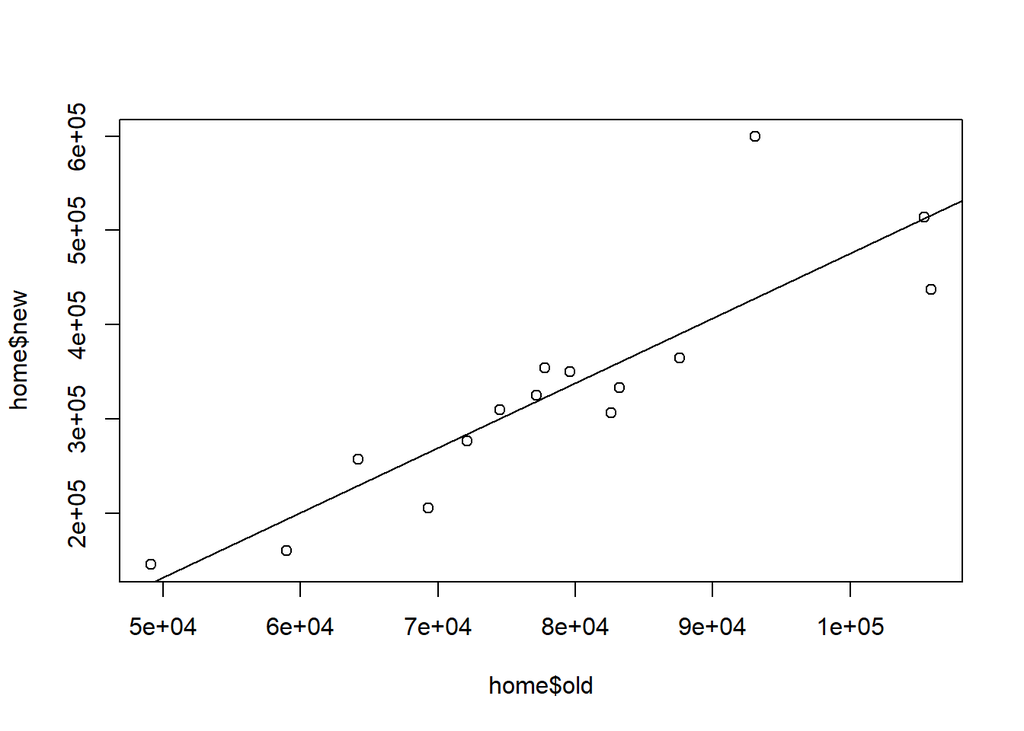

```r
> plot(home$old, home$new)
> lm(home$new ~ home$old)

Call:
lm(formula = home$new ~ home$old)

Coefficients:
(Intercept)     home$old
  -2.12e+05     6.88e+00
> abline(lm(home$new ~ home$old))
```

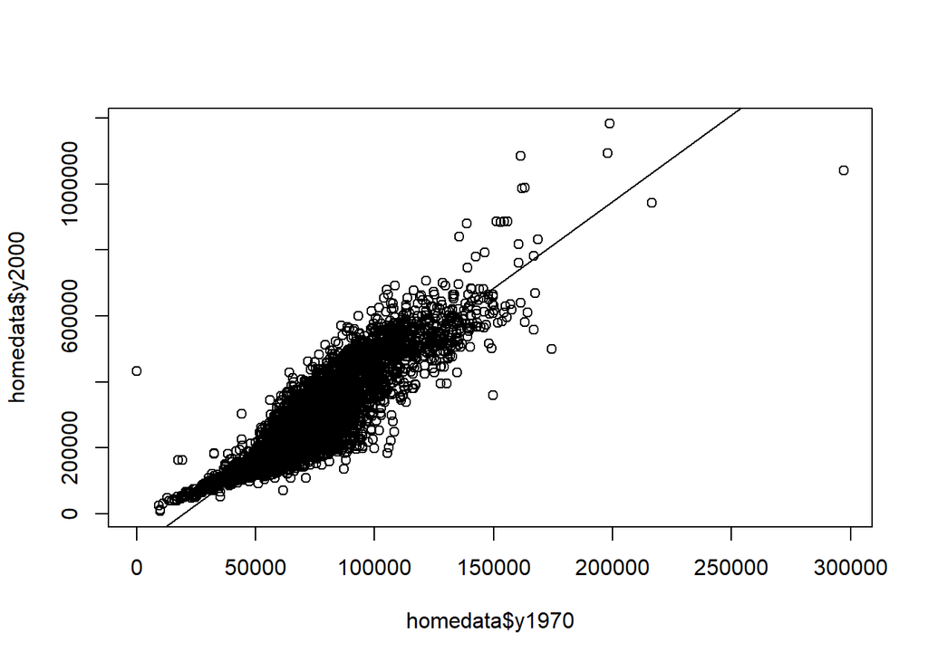

```r
> plot(homedata$y1970, homedata$y2000)
> lm(homedata$y2000 ~ homedata$y1970)

Call:
lm(formula = homedata$y2000 ~ homedata$y1970)

Coefficients:
   (Intercept)  homedata$y1970
     -1.04e+05        5.26e+00
> abline(lm(homedata$y2000 ~ homedata$y1970))
```

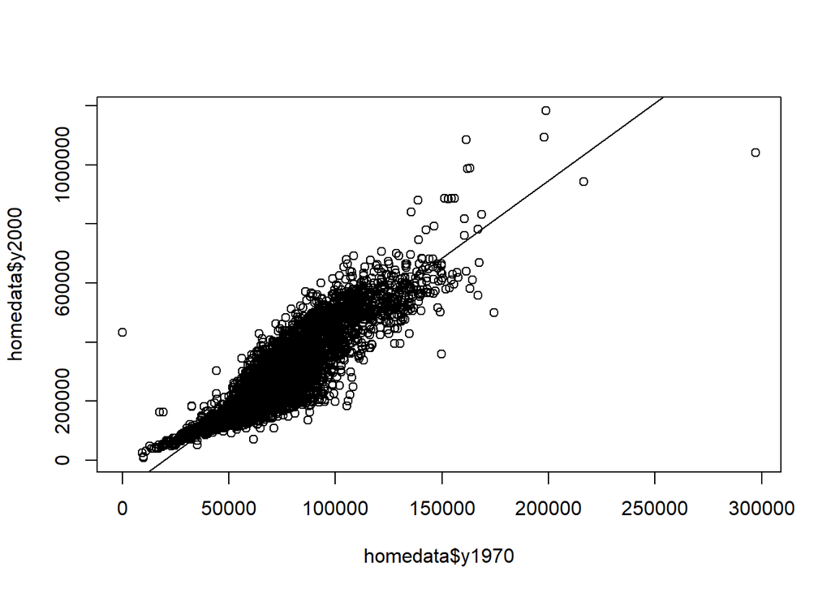

```r
> plot(homedata$y2000 ~ homedata$y1970)
> lm(homedata$y2000 ~ homedata$y1970)

Call:
lm(formula = homedata$y2000 ~ homedata$y1970)

Coefficients:
   (Intercept)  homedata$y1970
     -1.04e+05        5.26e+00
> abline(lm(homedata$y2000 ~ homedata$y1970))
```

`abline` function points lines on the current graph window  
`lm` function for the linear model  
The syntax `y ~ x` tells R to model the $y$ variable as a linear function of $x$